# Final Project

Data Science for Biologists, Spring 2021

Kevin C. Riedmuller

## Introduction

I have become more interested in government and politics recently and I think this will be a good opportunity to learn more about some government programs. The [US Kids Spending](https://github.com/rfordatascience/tidytuesday/blob/master/data/2020/2020-09-15/readme.md) data set includes spending data on children, by state, from the year 1997 to 2016. I chose this data because I think it will be really interesting to see how spending trends change over time and how spending on kids compares across different states. This data also includes what government programs the money is coming from such as SNAP or unemployment benefits. I am curious to see how much these government programs are providing relative to one another and how their contributions have also changed over time. Variable descriptions are located [here](https://jrosen48.github.io/tidykids/articles/tidykids-codebook.html).

```r
kids <- readr::read_csv('https://raw.githubusercontent.com/rfordatascience/tidytuesday/master/data/2020/2020-09-15/kids.csv')

glimpse(kids)
```

```
## Rows: 23,460
## Columns: 6
## $ state            <chr> "Alabama", "Alaska", "Arizona", "Arkansas", "Califor…
## $ variable         <chr> "PK12ed", "PK12ed", "PK12ed", "PK12ed", "PK12ed", "P…
## $ year             <dbl> 1997, 1997, 1997, 1997, 1997, 1997, 1997, 1997, 1997…
## $ raw              <dbl> 3271969, 1042311, 3388165, 1960613, 28708364, 333299…
## $ inf_adj          <dbl> 4665308.5, 1486170.0, 4830985.5, 2795523.0, 40933568…
## $ inf_adj_perchild <dbl> 3.929449, 7.548493, 3.706679, 3.891275, 4.282325, 4.…
```

## Question 1

#### How does SNAP benefit spending per child in New Jersey compare, over time, to other states in the Northeast after adjusting for inflation?

### Methods

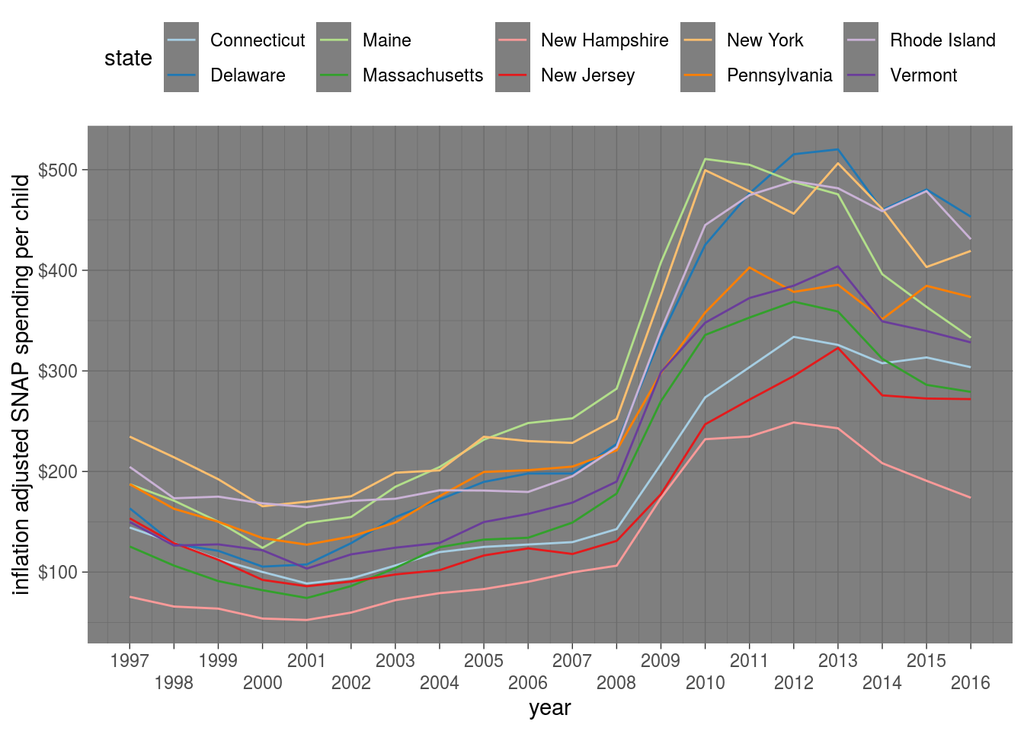

```r
kids %>% # pipe in dataset
  drop_na() -> kids_nona # remove rows containing na and define variable

# define variable containing all Northeast states
northeast_region <- c("New Jersey", "Delaware", "Pennsylvania",
                      "Maine", "New Hampshire", "Vermont", "Massachusetts",
                      "Rhode Island", "Connecticut", "New York")

kids_nona %>% # pipe in dataset
  select(- raw, -inf_adj) %>% # remove unnecessary columns
  filter(variable == "SNAP", # filter for rows containing SNAP information
         state %in% northeast_region) %>% # filter for rows containing Northeast states
  mutate(perchild_dollars = inf_adj_perchild * 1000) %>% # make a column to transform per $1000 values to dollar values
  ggplot() + # add ggplot
  aes(x = year, # add year to x-axis
      y = perchild_dollars, # add inflation adjusted amount per child to y-axis
      color = state) + # map color to state
  geom_line() + # add lines
  scale_color_brewer(palette = "Paired") + # change color palette
  theme_dark() + # add dark theme
  theme(legend.position = "top") + # move legend to the top
  scale_x_continuous(n.breaks = 19, # specify x-axis breaks
                     guide = guide_axis(n.dodge = 2)) + # specify x-axis label locations
  scale_y_continuous(labels = scales::dollar) + # change y-axis labels to dollar amounts
  labs(y = "inflation adjusted SNAP spending per child", # change y-axis title
       x = "year") # change x-axis title
```

### Answer

From 1997 to about 2002, New Jersey only spent more per child in SNAP benefits than Massachusetts and New Hampshire, and about the same as Connecticut. From about 2003 to 2016, New Jersey only spent more in SNAP benefits per child than New Hampshire.

## Question 2

#### On average, which Northeastern state spends the most money on parks and recreation services after adjusting for inflation?

### Methods

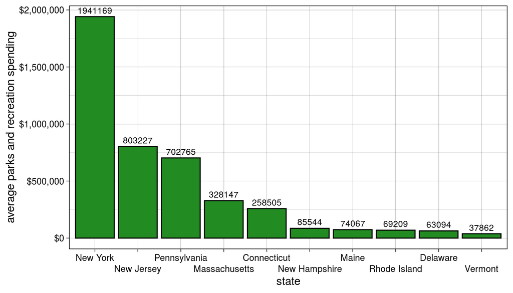

```r
kids_nona %>% # pipe in dataset
  select(state, variable, inf_adj) %>% # select columns of interest
  filter(variable == "parkrec", # filter rows for parks and recreation spending
         state %in% northeast_region) %>% # filter rows for Northeastern states
  group_by(state) %>% # group by state
  summarize(mean_parkrec = mean(inf_adj)) %>% # create a column of average parks and rec spending by state
  mutate(mean_parkrec0 = round(mean_parkrec, 0)) %>% # create column of average parks and rec spending without decimal points
  ungroup() %>% # ungroup data
  ggplot() + # add ggplot
  aes(x = fct_reorder(state, mean_parkrec0, .desc = TRUE), # add variable to x-axis and arrange in descending order of y-axis values
      y = mean_parkrec0) + # add variable to y-axis
  geom_col(color = "black", # add bars and specify color
             fill = "forestgreen") + # specify fill
  geom_text(aes(label = mean_parkrec0), # display bar values
            vjust = -.5, # adjust bar label height
            size = 3) + # adjust bar label size
  scale_y_continuous(labels = scales::dollar) + # change y-axis labels to dollar amounts
  scale_x_discrete(guide = guide_axis(n.dodge = 2)) + # stagger x-axis labels
  theme_linedraw() + # add linedraw theme
  labs(y = "average parks and recreation spending", # change y-axis label
       x = "state") # change x-axis label
```

### Answer

New York spends the most money on average for parks and recreation services in the Northeast after adjusting for inflation.

## Question 3

#### How has spending on Pell grants in New Jersey changed over time?

### Methods

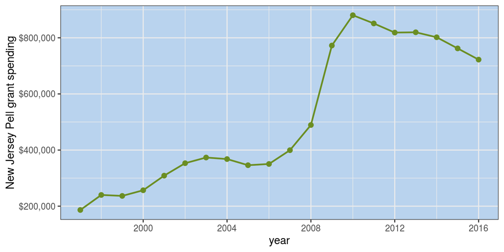

```r
kids_nona %>% # pipe in dataset
  select(state, variable, year, inf_adj) %>% # select column of interest
  filter(state == "New Jersey", # filter rows for New Jersey
         variable == "pell") %>% # filter rows for pell grant spending
  ggplot() + # add ggplot
  aes(x = year, # add year to x-axis
      y = inf_adj) + # add inflation adjusted spending to y-axis
  geom_line(color = "olivedrab", # add a line and specify color
            size = 0.8) + # specify line size
  geom_point(color = "olivedrab", # add points and specify color
             size = 2) + # specify point size
  scale_y_continuous(labels = scales::dollar) + # change y-axis labels to dollar amounts
  theme_bw() + # add bw theme
  labs(y = "New Jersey Pell grant spending") + # change y-axis label
  theme(panel.background = element_rect(fill = "slategray2")) + # change background fill
   scale_x_continuous(n.breaks = 7) # specify x-axis breaks
```

### Answer

New Jersey steadily increased Pell grant spending from 1997 to it’s highest peak of about $880,000 in 2010, with only slight decreases from 2003 to 2005. There was a decline in Pell grant spending from 2010 to 2016.

## Question 4

#### Which state in the Northeast spent the most on healthcare services collectively per child during the year of 2016?

### Methods

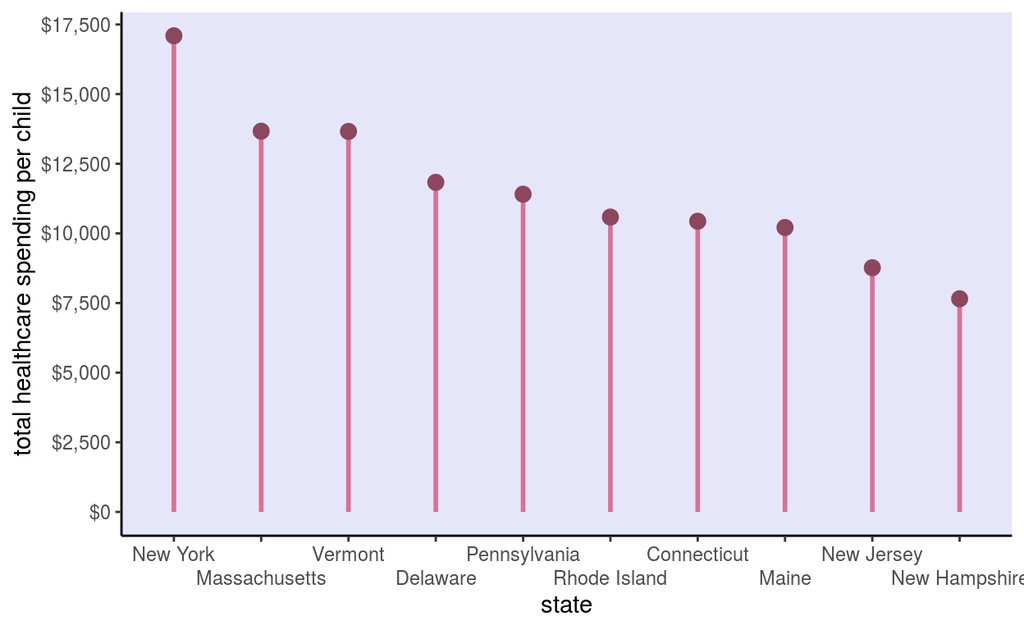

```r
# define variable containing healthcare services
healthcare <- c("Medicaid_CHIP", "other_health", "pubhealth")

# define variable containing target year
target_year <- 2016

kids_nona %>% # pipe in dataset
  select(-raw, -inf_adj) %>% # remove unnecessary rows
  filter(state %in% northeast_region, # filter rows for northeast states
         variable %in% healthcare, # filter rows for healthcare services
         year == target_year) %>% # filter rows for the year 2016
  group_by(state) %>% # group by state
  mutate(health_total = sum(inf_adj_perchild)) %>% # make a column that totals per child healthcare spending
  distinct(health_total) %>% # remove duplicate healthcare total outputs
  mutate(health_total_dollar = health_total*1000) %>% # make a column to transform per $1000 values to dollar values
  ungroup() %>% # ungroup data
  ggplot() + # add ggplot
  geom_segment(aes(x = fct_reorder(state, health_total_dollar, .desc = TRUE), # and lines in descending order and specify where line starts on x-axis
                   y = 0, # specify where line starts on y-axis
                   xend = state, # specify where line ends on x-axis
                   yend = health_total_dollar), # specify where line ends on y-axis
               size = 1, # specify line size
               color = "palevioletred") + # specify line color
  geom_point(aes(x = state, # add variable to x-axis
                 y = health_total_dollar), # add variable to y-axis
             size = 3, # specify point size
             color = "palevioletred4") + # specify point color
  scale_y_continuous(n.breaks = 8, # specify number of breaks on y-axis
                     labels = scales::dollar) + # change y-axis labels to dollar amounts
  scale_x_discrete(guide = guide_axis(n.dodge = 2)) + # stagger x-axis labels
  theme_classic() + # add classic theme
  theme(panel.background = element_rect(fill = "lavender")) + # specify background fill
  labs(x = "state", # change x-axis label
       y = "total healthcare spending per child") # change y-axis label
```

### Answer

At nearly $17,500 per child, New York spent the most on healthcare services in the Northeast in 2016.